# MEM5220 - Microeconometrics Self-Evaluation 1

Taltech - DEF

04 April, 2021

# Preface

This first R econometrics self-evaluation assignment is focused on data cleaning, data manipulation, plotting and estimating and interpreting simple linear regression models.  
Some packages I have used to solve the exercises:

```r
library(tidyverse)
library(modelsummary)
library(broom)
library(lmtest)
library(sandwich)
library(car)
```

You can use **any** additional packages for answering the questions.

**Note:**

- This assignment has to be solved in this R Markdown document and you should be able to “knit” the document without errors.
- Fill out your name in “yaml” - block on top of this document
- Use the R markdown syntax:
  - Write your code in code chunks
  - Write your explanations including the equations in markdown syntax
- If you have an error in your code use `#` to comment the line out where the error occurs but do not delete the code itself. I want to see your coding errors so I can give feedback!

For more information on using R Markdown for class exercises see https://ntaback.github.io/UofT_STA130/Rmarkdownforclassreports.html

You will be working with the dataset `Caschool` from the **Ecdat** package, the dataset `Wage1` from the **wooldrige** package. In the last two exercises, you will be working with a simulated data.

Try to answer by questions by including a code chunk and then a written answer. The answer to question 1.1 serves as a template. Please proceed with the rest of the questions in a similar way.

You can use any plotting package but the figures should have a research project style quality (eg. axis labels, figure legend, figure title and if necessary figures notes).

# 1 Caschool exercises

## 1.1 Question:

Load the dataset `Caschool` from the **Ecdat** package.

The Caschooldataset contains the average test scores of 420 elementary schools in California along with some additional information.

```r
# install.packages("Ecdat")
library("Ecdat")
data("Caschool", package = "Ecdat")
```

## 1.2 Question:

What are the dimensions of the `Caschool` dataset?

**A**:

```r
dim(Caschool)
```

```
[1] 420  17
```

The dataset has 420 rows and 17 columns.

## 1.3 Question:

Does the `Caschool` dataset contain missing observations?

**A**:

```r
sum(is.na(Caschool))
```

```
[1] 0
```

There are no missing observations in the dataset.

## 1.4 Question:

Display the structure of the `Caschool` dataset. Which variable are encoded as factors?

**A**:

```r
str(Caschool)
```

```
'data.frame':   420 obs. of  17 variables:
 $ distcod : int  75119 61499 61549 61457 61523 62042 68536 63834 62331 67306 ...
 $ county  : Factor w/ 45 levels "Alameda","Butte",..: 1 2 2 2 2 6 29 11 6 25 ...
 $ district: Factor w/ 409 levels "Ackerman Elementary",..: 362 214 367 132 270 53 152 383 263 94 ...
 $ grspan  : Factor w/ 2 levels "KK-06","KK-08": 2 2 2 2 2 2 2 2 2 1 ...
 $ enrltot : int  195 240 1550 243 1335 137 195 888 379 2247 ...
 $ teachers: num  10.9 11.1 82.9 14 71.5 ...
 $ calwpct : num  0.51 15.42 55.03 36.48 33.11 ...
 $ mealpct : num  2.04 47.92 76.32 77.05 78.43 ...
 $ computer: int  67 101 169 85 171 25 28 66 35 0 ...
 $ testscr : num  691 661 644 648 641 ...
 $ compstu : num  0.344 0.421 0.109 0.35 0.128 ...
 $ expnstu : num  6385 5099 5502 7102 5236 ...
 $ str     : num  17.9 21.5 18.7 17.4 18.7 ...
 $ avginc  : num  22.69 9.82 8.98 8.98 9.08 ...
 $ elpct   : num  0 4.58 30 0 13.86 ...
 $ readscr : num  692 660 636 652 642 ...
 $ mathscr : num  690 662 651 644 640 ...
```

County, district and grspan are encoded as factors.

## 1.5 Question:

Provide a summary statistic of the data.

**A**:

```r
summary(Caschool)
```

```
    distcod              county                         district     grspan
 Min.   :61382   Sonoma     : 29   Lakeside Union Elementary:  3   KK-06: 61
 1st Qu.:64308   Kern       : 27   Mountain View Elementary :  3   KK-08:359
 Median :67760   Los Angeles: 27   Jefferson Elementary     :  2
 Mean   :67473   Tulare     : 24   Liberty Elementary       :  2
 3rd Qu.:70419   San Diego  : 21   Ocean View Elementary    :  2
 Max.   :75440   Santa Clara: 20   Pacific Union Elementary :  2
                 (Other)    :272   (Other)                  :406
    enrltot           teachers          calwpct          mealpct
 Min.   :   81.0   Min.   :   4.85   Min.   : 0.000   Min.   :  0.00
 1st Qu.:  379.0   1st Qu.:  19.66   1st Qu.: 4.395   1st Qu.: 23.28
 Median :  950.5   Median :  48.56   Median :10.520   Median : 41.75
 Mean   : 2628.8   Mean   : 129.07   Mean   :13.246   Mean   : 44.71
 3rd Qu.: 3008.0   3rd Qu.: 146.35   3rd Qu.:18.981   3rd Qu.: 66.86
 Max.   :27176.0   Max.   :1429.00   Max.   :78.994   Max.   :100.00

    computer         testscr         compstu           expnstu
 Min.   :   0.0   Min.   :605.5   Min.   :0.00000   Min.   :3926
 1st Qu.:  46.0   1st Qu.:640.0   1st Qu.:0.09377   1st Qu.:4906
 Median : 117.5   Median :654.5   Median :0.12546   Median :5215
 Mean   : 303.4   Mean   :654.2   Mean   :0.13593   Mean   :5312
 3rd Qu.: 375.2   3rd Qu.:666.7   3rd Qu.:0.16447   3rd Qu.:5601
 Max.   :3324.0   Max.   :706.8   Max.   :0.42083   Max.   :7712

      str            avginc           elpct           readscr
 Min.   :14.00   Min.   : 5.335   Min.   : 0.000   Min.   :604.5
 1st Qu.:18.58   1st Qu.:10.639   1st Qu.: 1.941   1st Qu.:640.4
 Median :19.72   Median :13.728   Median : 8.778   Median :655.8
 Mean   :19.64   Mean   :15.317   Mean   :15.768   Mean   :655.0
 3rd Qu.:20.87   3rd Qu.:17.629   3rd Qu.:22.970   3rd Qu.:668.7
 Max.   :25.80   Max.   :55.328   Max.   :85.540   Max.   :704.0

    mathscr
 Min.   :605.4
 1st Qu.:639.4
 Median :652.5
 Mean   :653.3
 3rd Qu.:665.9
 Max.   :709.5
```

Other option is to use for example the skimr package:

```r
library(skimr)
skim(Caschool)
```

Data summary

| Name | Caschool |
| --- | --- |
| Number of rows | 420 |
| Number of columns | 17 |
| _______________________ |  |
| Column type frequency: |  |
| factor | 3 |
| numeric | 14 |
| ________________________ |  |
| Group variables | None |

**Variable type: factor**

| skim_variable | n_missing | complete_rate | ordered | n_unique | top_counts |
| --- | --- | --- | --- | --- | --- |
| county | 0 | 1 | FALSE | 45 | Son: 29, Ker: 27, Los: 27, Tul: 24 |
| district | 0 | 1 | FALSE | 409 | Lak: 3, Mou: 3, Jef: 2, Lib: 2 |
| grspan | 0 | 1 | FALSE | 2 | KK-: 359, KK-: 61 |

**Variable type: numeric**

| skim_variable | n_missing | complete_rate | mean | sd | p0 | p25 | p50 | p75 | p100 | hist |
| --- | --- | --- | --- | --- | --- | --- | --- | --- | --- | --- |
| distcod | 0 | 1 | 67472.81 | 3466.99 | 61382.00 | 64307.75 | 67760.50 | 70419.00 | 75440.00 | ▇▆▇▇▁ |
| enrltot | 0 | 1 | 2628.79 | 3913.10 | 81.00 | 379.00 | 950.50 | 3008.00 | 27176.00 | ▇▁▁▁▁ |
| teachers | 0 | 1 | 129.07 | 187.91 | 4.85 | 19.66 | 48.56 | 146.35 | 1429.00 | ▇▁▁▁▁ |
| calwpct | 0 | 1 | 13.25 | 11.45 | 0.00 | 4.40 | 10.52 | 18.98 | 78.99 | ▇▃▁▁▁ |
| mealpct | 0 | 1 | 44.71 | 27.12 | 0.00 | 23.28 | 41.75 | 66.86 | 100.00 | ▆▇▆▅▅ |
| computer | 0 | 1 | 303.38 | 441.34 | 0.00 | 46.00 | 117.50 | 375.25 | 3324.00 | ▇▁▁▁▁ |
| testscr | 0 | 1 | 654.16 | 19.05 | 605.55 | 640.05 | 654.45 | 666.66 | 706.75 | ▂▆▇▅▁ |
| compstu | 0 | 1 | 0.14 | 0.06 | 0.00 | 0.09 | 0.13 | 0.16 | 0.42 | ▂▇▃▁▁ |
| expnstu | 0 | 1 | 5312.41 | 633.94 | 3926.07 | 4906.18 | 5214.52 | 5601.40 | 7711.51 | ▂▇▃▁▁ |
| str | 0 | 1 | 19.64 | 1.89 | 14.00 | 18.58 | 19.72 | 20.87 | 25.80 | ▁▃▇▃▁ |
| avginc | 0 | 1 | 15.32 | 7.23 | 5.34 | 10.64 | 13.73 | 17.63 | 55.33 | ▇▃▁▁▁ |
| elpct | 0 | 1 | 15.77 | 18.29 | 0.00 | 1.94 | 8.78 | 22.97 | 85.54 | ▇▂▁▁▁ |
| readscr | 0 | 1 | 654.97 | 20.11 | 604.50 | 640.40 | 655.75 | 668.73 | 704.00 | ▂▆▇▆▂ |
| mathscr | 0 | 1 | 653.34 | 18.75 | 605.40 | 639.38 | 652.45 | 665.85 | 709.50 | ▁▆▇▃▁ |

## 1.6 Question:

What are the names of the variables in the dataset?

**A**:

```r
names(Caschool)
```

```
 [1] "distcod"  "county"   "district" "grspan"   "enrltot"  "teachers"
 [7] "calwpct"  "mealpct"  "computer" "testscr"  "compstu"  "expnstu"
[13] "str"      "avginc"   "elpct"    "readscr"  "mathscr"
```

## 1.7 Question:

How many unique observations are available in the variable “county”

**A**:

```r
unique(Caschool$county)
```

```
 [1] Alameda         Butte           Fresno          San Joaquin
 [5] Kern            Sacramento      Merced          Tulare
 [9] Los Angeles     Imperial        Monterey        San Diego
[13] San Bernardino  San Mateo       Ventura         Riverside
[17] Santa Clara     Madera          Santa Barbara   Orange
[21] Kings           Sonoma          Contra Costa    Humboldt
[25] Siskiyou        Lake            Sutter          Mendocino
[29] San Benito      Shasta          Tehama          Stanislaus
[33] Tuolumne        El Dorado       Placer          Glenn
[37] Lassen          Santa Cruz      Nevada          Calaveras
[41] Marin           San Luis Obispo Inyo            Trinity
[45] Yuba
45 Levels: Alameda Butte Calaveras Contra Costa El Dorado Fresno ... Yuba
```

## 1.8 Question:

Summarize the mean number of students grouped by county.

**A**:

```r
mean_countCaschool <- Caschool %>%
  group_by(county) %>%
  summarise(mean_count = mean(enrltot)) %>%
  arrange(desc(mean_count))
mean_countCaschool
```

| county | mean_count |
| --- | --- |
| Orange | 8223.9091 |
| San Bernardino | 6469.7000 |
| San Diego | 6170.2857 |
| Santa Clara | 5931.9000 |
| Los Angeles | 5830.9259 |
| Ventura | 4627.7778 |
| Monterey | 3549.4286 |
| Sacramento | 3511.4286 |
| San Mateo | 3289.2353 |
| Kern | 3108.3333 |

[output cut: 35 more lines]

## 1.9 Question:

Calculate the log of average income from of the Caschool dataset. Call the variable **logavginc** and add this variable to the dataset. Then, plot a histogram of the average income vs. a histogram of log average income. What do you observe?

**A**:

```r
Caschool$logavginc <- log(Caschool$avginc)
```

```r
library(patchwork)
library(ggpubr)
p1 <- ggplot(Caschool, aes(avginc)) +
  geom_histogram(show.legend = FALSE) +
  labs(title="Average income",
        x ="Avg. income")+
  theme_pubr()
p2 <- ggplot(Caschool, aes(logavginc)) +
  geom_histogram(show.legend = FALSE) +
  labs(title="Average income",
        x ="Log Avg. income")+
  theme_pubr()
```

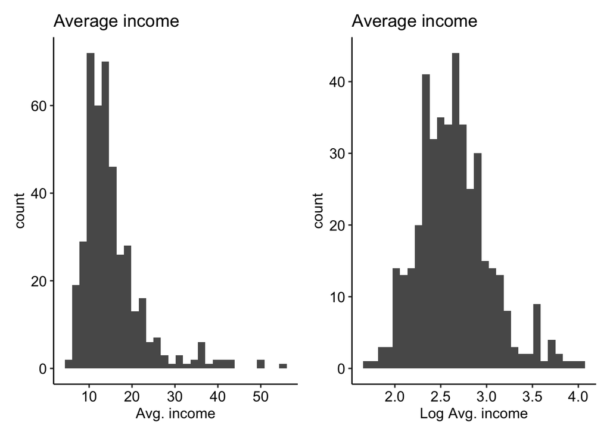

```r
patchwork <- (p1 + p2)
patchwork
```

## 1.10 Question:

We want to create now a subset of counties that have the ten highest district average income and that have the ten lowest district average income. Call this subset *Caschool_lowhighincome*.

**Hint**: One way is the create two subsets (eg. Cascholl_highincome and Caschool_lowincome and the use the `rbind()` function to bind them together.).

**A**:

```r
Caschool_highincome <- Caschool %>%
arrange(desc(avginc)) %>%
head(10)

Caschool_lowincome <- Caschool %>%
arrange((avginc)) %>%
head(10)

Caschool_lowhighincome <- rbind(Caschool_highincome,Caschool_highincome)
```

## 1.11 Question:

Let us test wether a high student/teacher ratio will be associated with higher-than-average test scores for the school? Create a scatter plot for the full dataset (*Caschool*) for the variables **testscr** and **str**.

**A**:

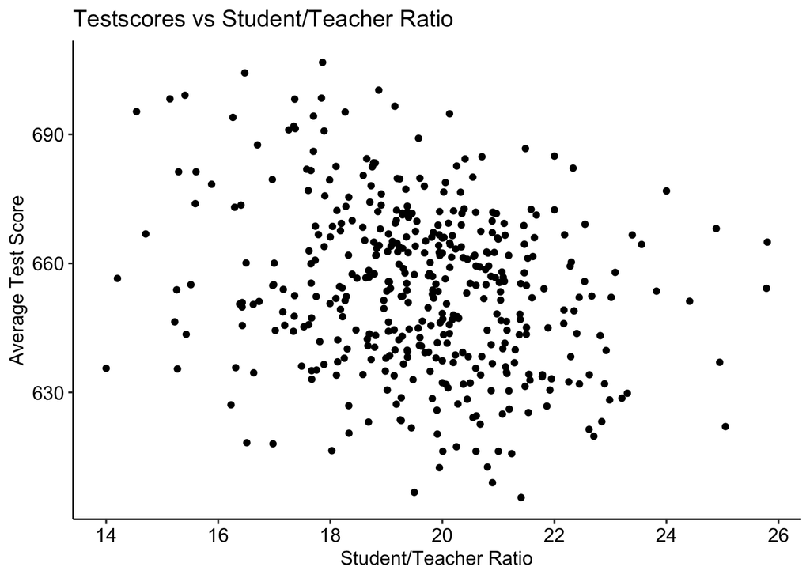

```r
ggplot(mapping = aes(x = str, y = testscr), data = Caschool) + # base plot
  geom_point() + # add points
  scale_y_continuous(name = "Average Test Score") +
  scale_x_continuous(name = "Student/Teacher Ratio") +
  labs(title="Testscores vs Student/Teacher Ratio")+
  theme_pubr()
```

## 1.12 Question:

Suppose a policymaker is interested in the following linear model:

$$\begin{equation}
\label{eq:1.1}
testscr = \beta_0 + \beta_1 str + u
\end{equation}$$

Where $testscr$ is the average test score for a given school and $str$ is the Student/Teacher Ratio (i.e. the average number of students per teacher).

Estimate the specified linear model. Is the estimated relationship between a schools Student/Teacher Ratio and its average test results positive or negative?

**A**:

```r
fit_single <- lm(formula = testscr ~ str, data = Caschool)
summary(fit_single)
```

```
Call:
lm(formula = testscr ~ str, data = Caschool)

Residuals:
    Min      1Q  Median      3Q     Max
-47.727 -14.251   0.483  12.822  48.540

Coefficients:
            Estimate Std. Error t value Pr(>|t|)
(Intercept) 698.9330     9.4675  73.825  < 2e-16 ***
str          -2.2798     0.4798  -4.751 2.78e-06 ***
---
Signif. codes:  0 '***' 0.001 '**' 0.01 '*' 0.05 '.' 0.1 ' ' 1

Residual standard error: 18.58 on 418 degrees of freedom
Multiple R-squared:  0.05124,   Adjusted R-squared:  0.04897
F-statistic: 22.58 on 1 and 418 DF,  p-value: 2.783e-06
```

## 1.13 Question:

Now, plot the regression line for the model we have just estimated.

**A**:

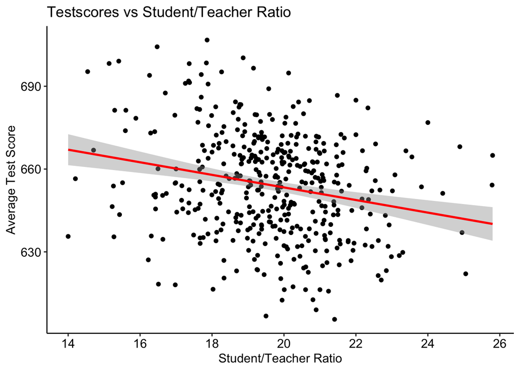

```r
ggplot(mapping = aes(x = str, y = testscr), data = Caschool) + # base plot
  geom_point() + # add points
  geom_smooth(method = "lm", size=1, color="red") + # add regression line
  scale_y_continuous(name = "Average Test Score") +
  scale_x_continuous(name = "Student/Teacher Ratio") +
  labs(title="Testscores vs Student/Teacher Ratio")+
  theme_pubr()
```

## 1.14 Question:

Let us extend our example of student test scores by adding families’ average income to our previous model:

$$\begin{equation}
\label{eq:1.2}
testscr = \beta_0 + \beta_1 str + \beta_2 avginc + u
\end{equation}$$

**A**:

```r
fit_multivariate <- lm(formula = "testscr ~ str + avginc", data = Caschool)
summary(fit_multivariate)
```

```
Call:
lm(formula = "testscr ~ str + avginc", data = Caschool)

Residuals:
    Min      1Q  Median      3Q     Max
-39.608  -9.052   0.707   9.259  31.898

Coefficients:
             Estimate Std. Error t value Pr(>|t|)
(Intercept) 638.72915    7.44908  85.746   <2e-16 ***
str          -0.64874    0.35440  -1.831   0.0679 .
avginc        1.83911    0.09279  19.821   <2e-16 ***
---
Signif. codes:  0 '***' 0.001 '**' 0.01 '*' 0.05 '.' 0.1 ' ' 1

Residual standard error: 13.35 on 417 degrees of freedom
Multiple R-squared:  0.5115,    Adjusted R-squared:  0.5091
F-statistic: 218.3 on 2 and 417 DF,  p-value: < 2.2e-16
```

Adding the explanatory variable “avginc” to the model, the estimated coefficient of the student/ teacher ratio becomes first smaller compared to the previous model and second insignificant at conventional levels.

## 1.15 Question:

Assume know that “str” depends also on the value of yet another regressor, “avginc”. Estimate the following model. Compare the sign of the estimate of $\beta_2$ and $\beta_3$. Interpret the results.

$$\begin{equation}
\label{eq:1.3}
testscr = \beta_0 + \beta_1 str + \beta_2 avginc + \beta_3 (str \times avginc) + u
\end{equation}$$

**A**:

```r
fit_inter = lm(formula = testscr ~ str + avginc + str*avginc, data = Caschool)
summary(fit_inter)
```

```
Call:
lm(formula = testscr ~ str + avginc + str * avginc, data = Caschool)

Residuals:
    Min      1Q  Median      3Q     Max
-41.346  -9.260   0.209   8.736  33.368

Coefficients:
             Estimate Std. Error t value Pr(>|t|)
(Intercept) 689.47473   14.40894  47.850  < 2e-16 ***
str          -3.40957    0.75980  -4.487 9.34e-06 ***
avginc       -1.62388    0.85214  -1.906   0.0574 .
str:avginc    0.18988    0.04646   4.087 5.24e-05 ***
---
Signif. codes:  0 '***' 0.001 '**' 0.01 '*' 0.05 '.' 0.1 ' ' 1

Residual standard error: 13.1 on 416 degrees of freedom
Multiple R-squared:  0.5303,    Adjusted R-squared:  0.527
F-statistic: 156.6 on 3 and 416 DF,  p-value: < 2.2e-16
```

We observe also that the estimate of $\beta_2$ changes signs and becomes negative, while the interaction effect $\beta_3$ is positive.

This means that an increase in str reduces average student scores (more students per teacher make it harder to teach effectively); that an increase in average district income in isolation actually reduces scores; and that the interaction of both increases scores (more students per teacher are actually a good thing for student performance in richer areas).

## 1.16 Question:

**A**:

```r
library(modelsummary)
modelsummary(list(fit_single, fit_multivariate, fit_inter),stars = TRUE )
```

|  | Model 1 | Model 2 | Model 3 |
| --- | --- | --- | --- |
| (Intercept) | 698.933*** | 638.729*** | 689.475*** |
|  | (9.467) | (7.449) | (14.409) |
| str | -2.280*** | -0.649* | -3.410*** |
|  | (0.480) | (0.354) | (0.760) |
| avginc |  | 1.839*** | -1.624* |
|  |  | (0.093) | (0.852) |
| str × avginc |  |  | 0.190*** |
|  |  |  | (0.046) |
| Num.Obs. | 420 | 420 | 420 |
| R2 | 0.051 | 0.511 | 0.530 |
| R2 Adj. | 0.049 | 0.509 | 0.527 |
| AIC | 3650.5 | 3373.7 | 3359.2 |
| BIC | 3662.6 | 3389.9 | 3379.4 |
| Log.Lik. | -1822.250 | -1682.856 | -1674.587 |
| F | 22.575 | 218.302 | 156.585 |

* p < 0.1, ** p < 0.05, *** p < 0.01

The adjusted $R^2$ is highest for the model 3, the model that includes an interaction term. AIC and BIC, two widely used information criteria, would also select model 3, relative to each of the other models (The relatively quality of the model is maximized when the information criterion is minimized).

# 2 Wage1 excercises

Wage data: These are data from the 1976 Current Population Survey. Source of the data is Wooldrige. Familiarize yourself with the dataset if necessary.

```r
# install.packages("wooldridge")
library("wooldridge")
data("wage1", package = "wooldridge")
```

## 2.1 Question

First, estimate the following model and test again for heteroscedasticity.

$$\begin{equation}
\label{eq:2.1}
wage = \beta_0 + \beta_1 female + \beta_3 educ + \beta_4 exper + u
\end{equation}$$

**A**:

```r
lm3_wage1 <- lm(wage~female+educ+exper, data=wage1)
summary(lm3_wage1)
```

```
Call:
lm(formula = wage ~ female + educ + exper, data = wage1)

Residuals:
    Min      1Q  Median      3Q     Max
-6.3856 -1.9652 -0.4931  1.1199 14.8217

Coefficients:
            Estimate Std. Error t value Pr(>|t|)
(Intercept) -1.73448    0.75362  -2.302   0.0218 *
female      -2.15552    0.27031  -7.974 9.74e-15 ***
educ         0.60258    0.05112  11.788  < 2e-16 ***
exper        0.06424    0.01040   6.177 1.32e-09 ***
---
Signif. codes:  0 '***' 0.001 '**' 0.01 '*' 0.05 '.' 0.1 ' ' 1

Residual standard error: 3.078 on 522 degrees of freedom
Multiple R-squared:  0.3093,    Adjusted R-squared:  0.3053
F-statistic: 77.92 on 3 and 522 DF,  p-value: < 2.2e-16
```

```r
lm3_bptest <- bptest(lm3_wage1)
lm3_bptest
```

```
    studentized Breusch-Pagan test

data:  lm3_wage1
BP = 36.904, df = 3, p-value = 4.821e-08
```

The test statistic of the BP-test is 36.9043336 and the corresponding p-value is smaller than 4.8208966^{-8}, so we can reject homoscedasticity for all reasonable significance levels.

```r
# coeftest(lm3_wage1, vcov=hccm)
cov3 <- hccm(lm3_wage1, type="hc3") # hc3 is the standard method
lm3_robust <- coeftest(lm3_wage1, vcovHC)
lm3_robust
```

```
t test of coefficients:

             Estimate Std. Error t value  Pr(>|t|)
(Intercept) -1.734481   0.868647 -1.9968   0.04637 *
female      -2.155517   0.260249 -8.2825 1.020e-15 ***
educ         0.602580   0.065005  9.2697 < 2.2e-16 ***
exper        0.064242   0.010113  6.3521 4.626e-10 ***
---
Signif. codes:  0 '***' 0.001 '**' 0.01 '*' 0.05 '.' 0.1 ' ' 1
```

## 2.2 Question:

Now, estimate the following model:

$$\begin{equation}
\label{eq:2.2}
log(wage) = \beta_0 + \beta_1 (married \times female) + \beta_3 educ + \beta_4 exper + beta_5 exper^2 + \beta_6 tenure + \beta_7 tenure^2 + u
\end{equation}$$

1. What is the reference group in this model?
2. Ceteris paribus, how much more wage do single males make relative to the reference group?
3. Ceteris paribus, how much more wage do single females make relative to the reference group?
4. Ceteris paribus, how much less do married females make than single females?
5. Do the results make sense economically. What socio-economic factors could explain the results?

**A**:

```r
lm2_wage1 <- lm(log(wage)~married*female+educ+exper+I(exper^2)+tenure+I(tenure^2), data=wage1)
summary(lm2_wage1)
```

```
Call:
lm(formula = log(wage) ~ married * female + educ + exper + I(exper^2) +
    tenure + I(tenure^2), data = wage1)

Residuals:
     Min       1Q   Median       3Q      Max
-1.89697 -0.24060 -0.02689  0.23144  1.09197

Coefficients:
                 Estimate Std. Error t value Pr(>|t|)
(Intercept)     0.3213781  0.1000090   3.213 0.001393 **
married         0.2126757  0.0553572   3.842 0.000137 ***
female         -0.1103502  0.0557421  -1.980 0.048272 *
educ            0.0789103  0.0066945  11.787  < 2e-16 ***
exper           0.0268006  0.0052428   5.112 4.50e-07 ***
I(exper^2)     -0.0005352  0.0001104  -4.847 1.66e-06 ***
tenure          0.0290875  0.0067620   4.302 2.03e-05 ***
I(tenure^2)    -0.0005331  0.0002312  -2.306 0.021531 *
married:female -0.3005931  0.0717669  -4.188 3.30e-05 ***
---
Signif. codes:  0 '***' 0.001 '**' 0.01 '*' 0.05 '.' 0.1 ' ' 1

Residual standard error: 0.3933 on 517 degrees of freedom
Multiple R-squared:  0.4609,    Adjusted R-squared:  0.4525
F-statistic: 55.25 on 8 and 517 DF,  p-value: < 2.2e-16
```

```r
library(scales) #  percent
df_lm2_wage1 <- tidy(lm2_wage1)
# Singe male
marriedmale <- df_lm2_wage1 %>%
  filter(term == "married") %>%
  dplyr::select(estimate) %>%
  pull() # pull out the single coefficient value of the dataframe
# Single female
singlefemale <- df_lm2_wage1 %>%
  filter(term == "female") %>%
  dplyr::select(estimate) %>%
  pull() # pull out the single coefficient value of the dataframe
marriedfemale <- df_lm2_wage1 %>%
  filter(term == "married:female") %>%
  dplyr::select(estimate) %>%
  pull() # pull out the single coefficient value of the dataframe
married<- df_lm2_wage1 %>%
  filter(term == "married") %>% #
  dplyr::select(estimate) %>%
  pull() # pull out the single coefficient value of the dataframe
```

```r
lm2_robust <- coeftest(lm2_wage1, vcovHC)
lm2_robust
```

```
t test of coefficients:

                  Estimate  Std. Error t value  Pr(>|t|)
(Intercept)     0.32137810  0.11151141  2.8820 0.0041157 **
married         0.21267568  0.05816944  3.6561 0.0002822 ***
female         -0.11035021  0.05785288 -1.9074 0.0570190 .
educ            0.07891028  0.00757178 10.4216 < 2.2e-16 ***
exper           0.02680057  0.00520490  5.1491 3.727e-07 ***
I(exper^2)     -0.00053525  0.00010817 -4.9480 1.016e-06 ***
tenure          0.02908752  0.00737872  3.9421 9.190e-05 ***
I(tenure^2)    -0.00053314  0.00027213 -1.9591 0.0506349 .
married:female -0.30059307  0.07328034 -4.1020 4.758e-05 ***
---
Signif. codes:  0 '***' 0.001 '**' 0.01 '*' 0.05 '.' 0.1 ' ' 1
```

1. Reference group: *single* and *male*
2. Cp. married males make 21% (`percent(marriedmale)`) more than single males.
3. Cp. a single female makes -11% (`percent(singlefemale)`) less than the reference group.
4. Married females make 9% (`percent(abs(marriedfemale) - abs(married))`) less than single females.
5. There seems to be a marriage premium[^1] for men but for women the marriage premium is negative.

## 2.3 Question:

Test for heteroscedasticity test in the estimated regression of the wage1 dataset. Do we reject homoscedasticity for all reasonable significance levels? Adjust for heteroscedasticity by using refined White heteroscedasticity-robust SE.

**A**:

```r
bptest(lm2_wage1)
```

```
    studentized Breusch-Pagan test

data:  lm2_wage1
BP = 13.189, df = 8, p-value = 0.1055
```

We do not reject the null hypothesis at conventional significance levels.

## 2.4 Question

**A**:

```r
modelsummary(list(lm3_wage1, coeftest(lm3_wage1, vcovHC), lm2_wage1, coeftest(lm2_wage1, vcovHC)), stars = TRUE, notes = "Model 2 and Mode 4 have been estimated with robust standard errors.")
```

```
Original model not retained as part of coeftest object. For additional model summary information (r.squared, df, etc.), consider passing `glance.coeftest()` an object where the underlying model has been saved, i.e.`lmtest::coeftest(..., save = TRUE)`.
```

|  | Model 1 | Model 2 | Model 3 | Model 4 |
| --- | --- | --- | --- | --- |
| (Intercept) | -1.734** | -1.734** | 0.321*** | 0.321*** |
|  | (0.754) | (0.869) | (0.100) | (0.112) |
| female | -2.156*** | -2.156*** | -0.110** | -0.110* |
|  | (0.270) | (0.260) | (0.056) | (0.058) |
| educ | 0.603*** | 0.603*** | 0.079*** | 0.079*** |
|  | (0.051) | (0.065) | (0.007) | (0.008) |
| exper | 0.064*** | 0.064*** | 0.027*** | 0.027*** |
|  | (0.010) | (0.010) | (0.005) | (0.005) |
| married |  |  | 0.213*** | 0.213*** |
|  |  |  | (0.055) | (0.058) |
| I(exper^2) |  |  | -0.001*** | -0.001*** |
|  |  |  | (0.000) | (0.000) |
| tenure |  |  | 0.029*** | 0.029*** |
|  |  |  | (0.007) | (0.007) |
| I(tenure^2) |  |  | -0.001** | -0.001* |
|  |  |  | (0.000) | (0.000) |
| married × female |  |  | -0.301*** | -0.301*** |
|  |  |  | (0.072) | (0.073) |
| Num.Obs. | 526 | 526 | 526 | 526 |
| R2 | 0.309 |  | 0.461 |  |
| R2 Adj. | 0.305 |  | 0.453 |  |
| AIC | 2681.5 | 2681.5 | 521.9 | 521.9 |
| BIC | 2702.8 | 2702.8 | 564.6 | 564.6 |
| Log.Lik. | -1335.736 | -1335.736 | -250.955 | -250.955 |
| F | 77.920 |  | 55.246 |  |

Model 2 and Mode 4 have been estimated with robust standard errors.  
* p < 0.1, ** p < 0.05, *** p < 0.01

# 3 Collinearity exercises

This exercise focuses on the **collineartiy** problem.

## 3.1 Question:

Run the following commands in R:

```r
set.seed(1)
x1 <- runif(100)
x2 <- 0.5 * x1 + rnorm(100)/10
y <- 2 +2*x1 + 0.3 *x2 +rnorm(100)
```

The last line corresponds to creating a linear model in which $y$ is a function of $x_1$ and $x_2$. Write out the form of the linear model. What are the regression coefficients?

**A**:

$y = 2 +2x_1 + 0.3x_2 + \epsilon$

$\beta_0 = 2$, $\beta_1 = 2$, $\beta_3 = 0.3$

## 3.2 Question:

What is the correlation between $x_1$ and $x_2$? Create a scatterplot displaying the relationship between the variables.

**A**:

```r
cor(x1, x2)
```

```
[1] 0.8351212
```

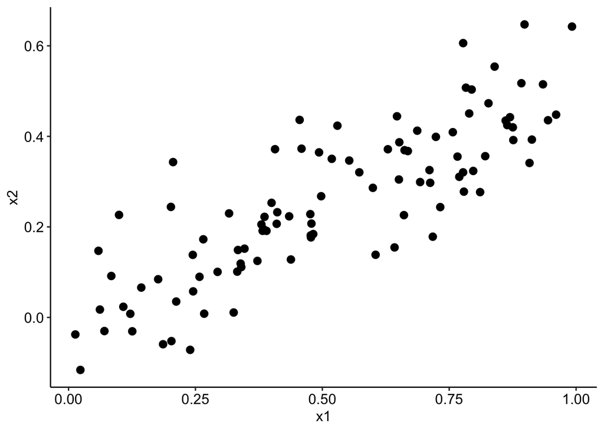

```r
d <-  data.frame(x1,x2)
ggplot(d, aes(x1, x2)) +
  geom_point(shape = 16, size = 3, show.legend = FALSE) +
  theme_pubr()
```

## 3.3 Question:

Using this data, fit a least squares regression to predict $y$ using $x_1$ and $x_2$. Describe the results obtained. What are $\hat{\beta_0}$, $\hat{\beta_1}$ and $\hat{\beta_2}$? How do these relate to the true $\beta_0$, $\beta_1$ and $\beta_2$? Can you reject the null hypothesis $H_0: \beta_1 =0$? How about the null hypothesis $H_0: \beta_2 =0$?

**A**:

```r
lm.fit = lm(y~x1+x2)
summary(lm.fit)
```

```
Call:
lm(formula = y ~ x1 + x2)

Residuals:
    Min      1Q  Median      3Q     Max
-2.8311 -0.7273 -0.0537  0.6338  2.3359

Coefficients:
            Estimate Std. Error t value Pr(>|t|)
(Intercept)   2.1305     0.2319   9.188 7.61e-15 ***
x1            1.4396     0.7212   1.996   0.0487 *
x2            1.0097     1.1337   0.891   0.3754
---
Signif. codes:  0 '***' 0.001 '**' 0.01 '*' 0.05 '.' 0.1 ' ' 1

Residual standard error: 1.056 on 97 degrees of freedom
Multiple R-squared:  0.2088,    Adjusted R-squared:  0.1925
F-statistic:  12.8 on 2 and 97 DF,  p-value: 1.164e-05
```

## 3.4 Question:

Now fit least squares regression to predict $y$ using only $x_1$. Comment on your results. Can you reject the null hypothesis $H_0: \beta_1=0$?

**A**:

```r
lm.fit = lm(y~x1)
summary(lm.fit)
```

```
Call:
lm(formula = y ~ x1)

Residuals:
     Min       1Q   Median       3Q      Max
-2.89495 -0.66874 -0.07785  0.59221  2.45560

Coefficients:
            Estimate Std. Error t value Pr(>|t|)
(Intercept)   2.1124     0.2307   9.155 8.27e-15 ***
x1            1.9759     0.3963   4.986 2.66e-06 ***
---
Signif. codes:  0 '***' 0.001 '**' 0.01 '*' 0.05 '.' 0.1 ' ' 1

Residual standard error: 1.055 on 98 degrees of freedom
Multiple R-squared:  0.2024,    Adjusted R-squared:  0.1942
F-statistic: 24.86 on 1 and 98 DF,  p-value: 2.661e-06
```

Yes, we can reject the null hypothesis for the regression coefficient given the p-value for its t-statistic is near zero.

## 3.5 Question:

Now fit least squares regression to predict $y$ using only $x_2$. Comment on your results. Can you reject the null hypothesis $H_0: \beta_2=0$?

**A**:

```r
lm.fit = lm(y~x2)
summary(lm.fit)
```

```
Call:
lm(formula = y ~ x2)

Residuals:
     Min       1Q   Median       3Q      Max
-2.62687 -0.75156 -0.03598  0.72383  2.44890

Coefficients:
            Estimate Std. Error t value Pr(>|t|)
(Intercept)   2.3899     0.1949   12.26  < 2e-16 ***
x2            2.8996     0.6330    4.58 1.37e-05 ***
---
Signif. codes:  0 '***' 0.001 '**' 0.01 '*' 0.05 '.' 0.1 ' ' 1

Residual standard error: 1.072 on 98 degrees of freedom
Multiple R-squared:  0.1763,    Adjusted R-squared:  0.1679
F-statistic: 20.98 on 1 and 98 DF,  p-value: 1.366e-05
```

Yes, we can reject the null hypothesis for the regression coefficient given the p-value for its t-statistic is near zero.

## 3.6 Question:

Do the results from the previous questions contradict each other? Explain your answer.

**A**:

No, because $x_1$ and $x_2$ have collinearity, it is hard to distinguish their effects when regressed upon together. When they are regressed upon separately, the linear relationship between y and each predictor is indicated more clearly.

# 4 Simulation exercises

## 4.1 Question:

The probability that a baby is girl or boy is approximately 48.8% or 51.2%, respectively, and these do not much very much across the world. Suppose that 400 babies are born in a hospital in a given year. How many will be girls?

Set a seed (eg. `set.seed(123)`) to make the result reproducible!

**A**:

```r
set.seed(123)
n_girls <- rbinom(1, 400, 0.488)
n_girls
```

```
[1] 189
```

## 4.2 Question:

Simulate the process 1000 times and plot the distribution. Indicate the mean in the distribution plot.

**A**:

```r
n_sims <- 1000
n_girls <- rbinom(n_sims, 400, 0.488)
```

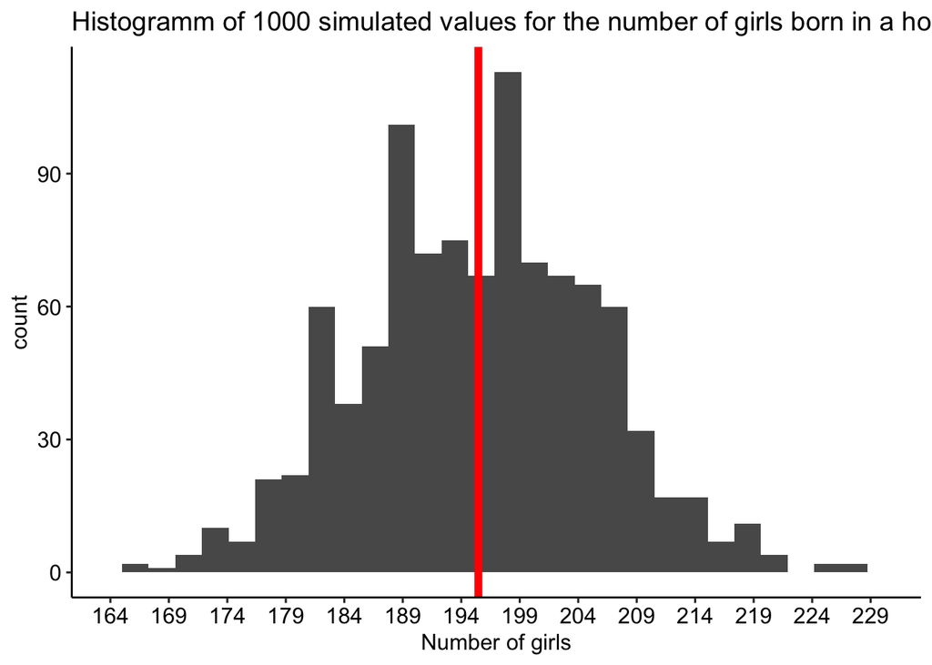

```r
n_girls <- as.data.frame(n_girls)
ggplot(n_girls, aes(n_girls)) +
  geom_histogram(show.legend = FALSE) +
  scale_x_continuous(breaks = seq(min(n_girls), 300, 5), lim = c(min(n_girls), max(n_girls))) +
  geom_vline(aes(xintercept = mean(n_girls)),col='red',size=2)+
  labs(title="Histogramm of 1000 simulated values for the number of girls born in a hospital from 400 births.",
        x ="Number of girls")+
  theme_pubr()
```

## 4.3 Question:

In the previous exercise we simulated a discrete probability model. Now, we will simulate a mixed discrete/ continuous model.

In the United States 52% of the adults are women and 48% are men. The heights of the men are approximately normally distributed wit mean 69.1 inches and standard deviation 2.9. Women have a mean height of 63.7 inches and a standard deviation of 2.7.

Generate the height of one randomly chosen adult (random adult means that this can either be a man or a women). Don’t forget to set a seed. How tall is that person? What gender does that random person probably have?

**A**:

```r
set.seed(123)
N <- 10
male <- rbinom(1,1,0.48)
height <- ifelse(male==1, rnorm(N, 69.1, 2.9), rnorm(1, 63.7, 2.7))
avg_height <- mean(height)
```

## 4.4 Question:

Now, simulate the distribution of the average height by generating 1000 draws. Plot the distribution of the average height of those 10 adults.

**A**:

```r
n_sims < 1000
```

```
[1] FALSE
```

```r
avg_height <- rep(NA, n_sims)
for (s in 1:n_sims) {
  N <- 10
male <- rbinom(1,1,0.48)
height <- ifelse(male==1, rnorm(N, 69.1, 2.9), rnorm(1, 63.7, 2.7))
avg_height[s] <- mean(height)
}
```

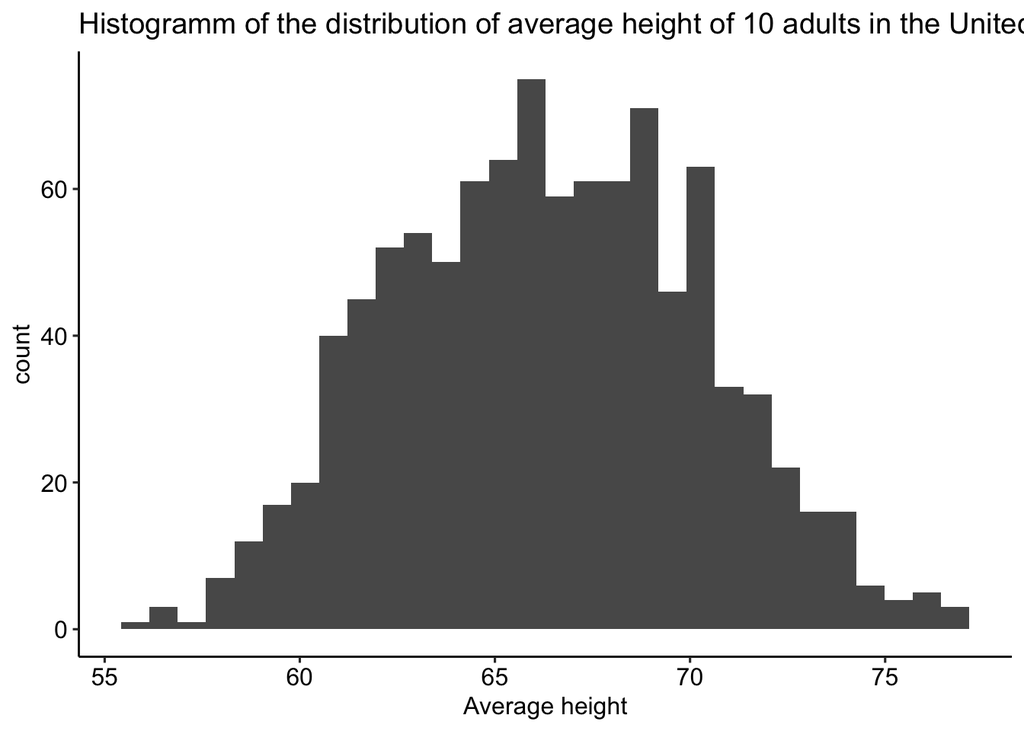

```r
avg_height <- as.data.frame(avg_height)
ggplot(avg_height, aes(avg_height)) +
  geom_histogram(show.legend = FALSE) +
  labs(title="Histogramm of the distribution of average height of 10 adults in the United States",
        x ="Average height")+
  theme_pubr()
```

## 4.5 Question:

Finally, instead of estimating the average height of 10 people, simulate the same model and extract the maximum height of 10 people. Plot the distribution.

**A**:

```r
max_height <- rep(NA, n_sims)
for (s in 1:n_sims) {
  N <- 10
male <- rbinom(1,1,0.48)
height <- ifelse(male==1, rnorm(N, 69.1, 2.9), rnorm(1, 63.7, 2.7))
max_height[s] <- max(height)
avg_height[s] <- mean(height)
}
```

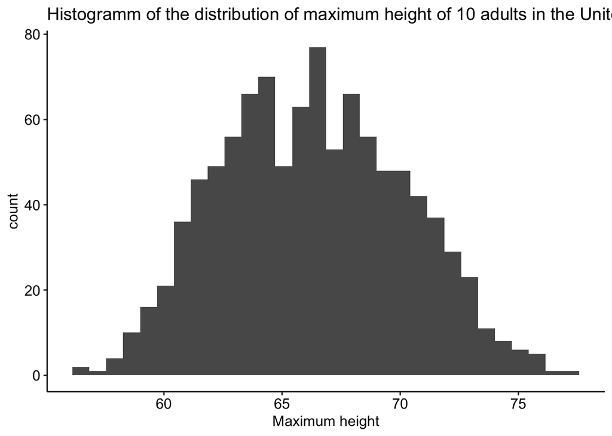

```r
max_height <- as.data.frame(max_height)
ggplot(max_height, aes(max_height)) +
  geom_histogram(show.legend = FALSE) +
  labs(title="Histogramm of the distribution of maximum height of 10 adults in the United States",
        x ="Maximum height")+
  theme_pubr()
```

[^1]: There is clearly a correlation between men having children and men getting higher salaries, and the reverse for women. However, this may reflect the fact that women are more likely to withdraw from work to take care of children (regardless of whether they’d prefer to), and men may double down on work.